# HW4(2014_10451)

### Ex. 11.19

```r
p=8
n=5
m=30
alpha=0.01

const<-((m+1)*(n-1)*p)/(m*(n-1)-p+1) #constant in case of mu, sigma unknown, n>=2
UCL_F<-const*qf(1-alpha,df1=p,df2=m*(n-1)-p+1)
UCL_F
```

```
## [1] 23.46194
```

```r
UCL_chisq<-qchisq(1-alpha,p)
UCL_chisq
```

```
## [1] 20.09024
```

```r
while (1){
  UCL_F<-((m+1)*(n-1)*p)/(m*(n-1)-p+1)*qf(1-alpha,df1=p,df2=m*(n-1)-p+1)
  if(UCL_chisq>(0.99*UCL_F)) break
  m=m+1
}
m #m=450 to be UCL from chi-square dist is over 0.99*UCL from F dist
```

```
## [1] 450
```

1. mu0, sigma0가 unknown일 때 Phase II data를 분석하기 위한 HT 통계량에 대한 UCL은 적당한 상수와 dof1=p, dof2=m(n-1)+1-p인 F분포에 의해 결정되고 그 값은 23.46이다.
2. 한편, mu0, sigma0가 known이라면 Phase 구분 없이 HT 통계량은 dof=p인 카이제곱분포에 의해 결정되며 그 값은 20.09이다. F분포에서의 UCL이 chi-square의 그것보다 더 큰데, 이는 unknown일 때 모수의 추정치를 사용하기 때문에 같은 유의수준에 대해 신뢰구간이 넓어진 것으로 해석할 수 있다.
3. F분포에서 m이 커지면 F 분포를 이용한 UCL은 점점 감소하여 카이제곱의 UCL에 가까워지는데, m=450에서 둘의 차이가 1% 미만임을 알 수 있다.

### 4.

```r
library(ggplot2)
data<-read.csv("./table7_9.csv")
head(data)
```

```
##   X    X1    X2   X3    X4    X5    X6
## 1 1 -0.12  0.36 0.40  0.25  1.37 -0.13
## 2 2 -0.60 -0.35 0.04 -0.28 -0.25 -0.15
## 3 3 -0.13  0.05 0.84  0.61  1.45  0.25
## 4 4 -0.46 -0.37 0.30  0.00 -0.12 -0.25
## 5 5 -0.46 -0.24 0.37  0.13  0.78 -0.15
## 6 6 -0.46 -0.16 0.07  0.10  1.15 -0.18
```

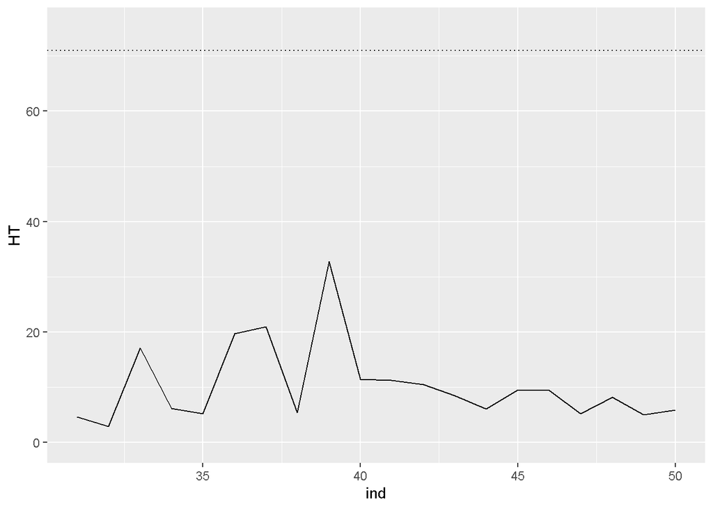

```r
varname<-names(data)[2:7] #names of variables X1, X2, .. X6

ind_IC<-1:30
ind_target<-31:50
m<-15
p<-6
alpha<-0.005

xbar<-as.matrix(apply(data[ind_IC,varname],2,mean)) #apply mean by column for all Phase I sample, do as.matrix
Sbar<-cov(data[ind_IC,varname]) #Sbar = covariance matrices for Phase I sample

HT<-NULL
for(i in ind_target){
  y<-t(data[i,varname]) #transpose needed
  HT_tmp<-t(y-xbar)%*%solve(Sbar)%*%(y-xbar)
  HT<-c(HT,HT_tmp)
}

const<-((m+1)*(m-1)*p)/(m*(m-p)) #constant in case of mu, sigma unknown, n=1
UCL<-const*qf(1-alpha,df1=p,df2=m-p) #qf to get quantile(1-alpha)
data_HT<-data.frame(HT=HT,ind=ind_target) #HT statistics of data in Phase II
ggplot(data_HT, aes(x=ind,y=HT))+
  geom_line()+
  geom_abline(slope=0, intercept=UCL, lty="dotted")+#draw UCL line
  ylim(0,75)
```

처음 30개 데이터를 In control이라 가정하므로 이는 Phase I 단계로 볼 수 있으며, 이 구간에 속한 데이터를 이용하여 mu와 S의 추정량, 그리고 UCL을 구한다. 이를 이용해 그 다음 31~50번째 데이터에 대한 HT 통계량이 UCL보다 작음을 plot으로 확인하였다. 따라서 공정은 Phase II에서도 In control 상태이며, 평균과 분산의 shifting이 일어나지 않았음을 알 수 있다.

### 5.

```r
data<-read.csv("./table7_9.csv")
head(data)
```

```
##   X    X1    X2   X3    X4    X5    X6
## 1 1 -0.12  0.36 0.40  0.25  1.37 -0.13
## 2 2 -0.60 -0.35 0.04 -0.28 -0.25 -0.15
## 3 3 -0.13  0.05 0.84  0.61  1.45  0.25
## 4 4 -0.46 -0.37 0.30  0.00 -0.12 -0.25
## 5 5 -0.46 -0.24 0.37  0.13  0.78 -0.15
## 6 6 -0.46 -0.16 0.07  0.10  1.15 -0.18
```

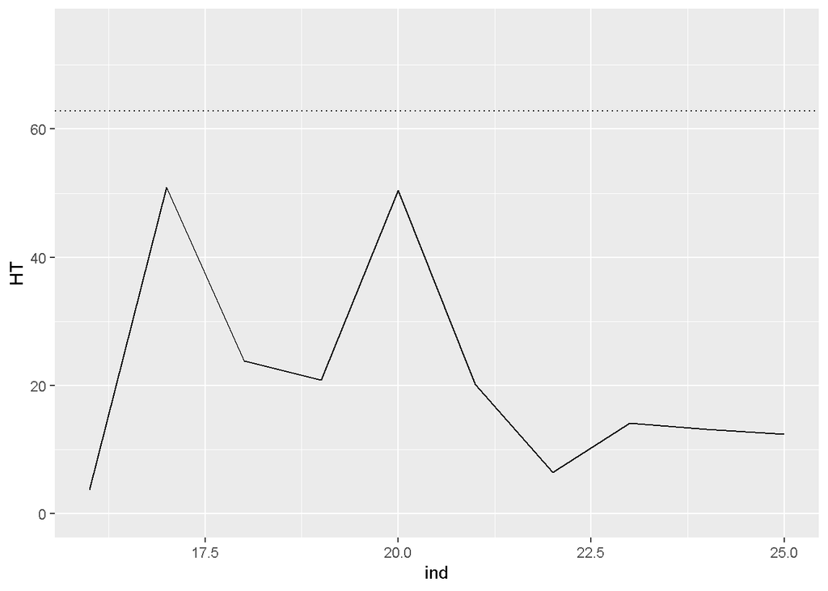

```r
data$batch<-rep(1:25, each=2) #grouping by 1 1 2 2 3 3 4 4 ..
varname<-names(data)[2:7] #names of variables X1, X2, .. X6

ind_IC<-1:15
ind_target<-16:25
m<-15
n<-2
p<-6
alpha<-0.005

xbar<-do.call(rbind,lapply(1:25,function(j){ #apply function() for all batches, then rbind
  apply(data[data$batch==j,varname],2,mean) #apply mean by column for batch number j sample
}))

xbarbar<-apply(xbar[ind_IC,],2,mean) #apply mean by column throughout all batches considered I.C.,Phase I.

Sbar<-Reduce("+",lapply(ind_IC,function(j){
  Smat<-cov(data[data$batch==j,varname])
  return (Smat)
}))/length(ind_IC) #Sbar equals mean of covariance matrices for all batches considered I.C.,Phase I.

HT<-NULL
for(i in ind_target){
  ybar<-xbar[i,]
  HT_tmp<-n*t(ybar-xbarbar)%*%solve(Sbar)%*%(ybar-xbarbar)
  HT<-c(HT,HT_tmp)
}

const<-((m+1)*(n-1)*p)/(m*(n-1)-p+1) #constant in case of mu, sigma unknown, n>=2
UCL<-const*qf(1-alpha,df1=p,df2=m*(n-1)-p+1) #qf to get quantile(1-alpha)
data_HT<-data.frame(HT=HT,ind=ind_target) #HT statistics of data in Phase II
ggplot(data_HT, aes(x=ind,y=HT))+
  geom_line()+
  geom_abline(slope=0, intercept=UCL, lty="dotted")+#draw UCL line
  ylim(0,75)
```

4번 문제와 동일한 Phase I, Phase II split이지만 여기서는 1 batch 당 2개의 데이터로 group화하여 분석한다. 따라서 S와 그에 따른 HT 통계량, UCL이 4번의 것과 약간 달라진다. 그러나 16~25번 batch에 대한 HT 통계량이 UCL보다 작고, 공정은 이 분석 방법에서도 In control 상태, 평균과 분산의 shifting이 일어나지 않았다는 결론을 얻는다.